# Statistics for Bioengineering - Week 10

Author

Bill Cresko

# Week 10: Unsupervised ML Methods

## Week 10 Topics

- Introduction to multivariate statistics and unsupervised learning
- Principal Component Analysis (PCA) — theory and practice
- Principal Coordinate Analysis (PCoA) ordination
- Nonmetric Multidimensional Scaling (NMDS) ordination
- Dimensionality reduction with t-SNE and UMAP
- Clustering: hierarchical, K-means, and K-nearest neighbors
- Course summary and method selection guide

**Note**

**Readings:** Chapters 36–40

**Final project due next week**

## Packages for This Week

**Install**

```r
# Install new packages (run once)
install.packages(c("vegan", "Rtsne", "umap", "ape",
                    "cluster", "dendextend", "class", "plotly",
                    "gridExtra", "cowplot"))
```

**Load**

```r
library(tidyverse)    # Data manipulation & visualization
library(vegan)        # Community ecology ordination
library(Rtsne)        # t-SNE implementation
library(umap)         # UMAP implementation
library(ape)          # PCoA
library(cluster)      # Clustering algorithms (silhouette, etc.)
library(dendextend)   # Enhanced dendrogram visualization
library(class)        # K-nearest neighbors classification
library(plotly)       # Interactive 3D visualization
library(gridExtra)    # Multi-panel figure arrangement
library(cowplot)      # Legend extraction
```

# Introduction to Multivariate Statistics

## The Multivariate Challenge

In bioengineering research, we rarely measure just one variable at a time.

- Gene expression profiling produces thousands of measurements per sample.
- Biomaterial characterization involves dozens of correlated physical and chemical properties.
- Clinical studies track many biomarkers simultaneously.

**The fundamental problem:** How do we find meaningful patterns when our data has many more variables than we can visualize or easily interpret?

**Unsupervised methods** address this by discovering structure in the data without requiring predefined labels or categories. They answer questions like:

- Are there natural groupings among these samples?
- Which variables contribute most to differences?
- Can we reduce 100 measurements to a few meaningful dimensions?

## When to Use Unsupervised Multivariate Methods

Unsupervised methods are appropriate when you want to **explore** and **discover** rather than **predict** or **test**:

**Use unsupervised methods when:**

- You have many correlated variables and want to identify the dominant patterns of variation
- You suspect natural groupings exist but don’t know what they are
- You need to reduce dimensionality before applying other statistical methods
- You want to visualize high-dimensional data in 2D or 3D
- You are performing quality control — looking for outliers, batch effects, or unexpected structure

**Do NOT use unsupervised methods when:**

- You have a clear response variable and want to test specific hypotheses (use regression, ANOVA, etc.)
- You need causal inference (unsupervised methods are descriptive)
- Your data has only a few variables that can be examined individually

## Overview of Common Methods

| Method | Input | Goal | Key Output |
| --- | --- | --- | --- |
| **PCA** | Raw data matrix | Find axes of maximum variance | Scores, loadings, variance explained |
| **PCoA** | Distance matrix | Metric ordination in reduced space | Coordinates preserving distances |
| **NMDS** | Distance matrix | Non-metric ordination | Coordinates preserving rank-order |
| **t-SNE** | Raw data or distances | Visualize local cluster structure | 2D embedding |
| **UMAP** | Raw data or distances | Visualize local + global structure | 2D embedding |
| **Hierarchical clustering** | Distance matrix | Find nested group structure | Dendrogram |
| **K-means** | Raw data matrix | Partition into k groups | Cluster assignments |
| **KNN** | Labeled training data | Classify new observations | Predicted labels |

## Bioengineering Case Examples

**Single-cell genomics:** PCA reduces 20,000+ gene expression measurements to 50 principal components, then UMAP visualizes cell populations in 2D. Clustering identifies distinct cell types.

**Biomaterial formulation screening:** Dozens of physical properties (porosity, modulus, degradation rate, swelling) measured across hundreds of formulations. Hierarchical clustering groups similar formulations. PCA identifies which properties drive the main differences.

**Drug response profiling:** Gene expression measured in tissue samples before and after treatment. PCA reveals whether treatment dominates the variation. PERMANOVA tests whether treated and untreated groups differ significantly in multivariate space.

**Microbiome analysis:** Species abundance data from gut samples. Bray-Curtis distance captures compositional differences. PCoA and NMDS visualize community differences between patient groups.

## Interactive 3D Multivariate Data Cloud

**Output**

[interactive chart not shown]

**Code**

```r
library(plotly)

# Generate football-shaped data cloud
set.seed(42)
n <- 200
pc1 <- rnorm(n, 0, 4)  # Most variance
pc2 <- rnorm(n, 0, 2)  # Moderate
pc3 <- rnorm(n, 0, 1)  # Least

# Rotate into 3D space
angle1 <- pi/6; angle2 <- pi/4
x <- pc1 * cos(angle1) - pc2 * sin(angle1)
y <- pc1 * sin(angle1) * cos(angle2) + pc2 * cos(angle1) * cos(angle2) - pc3 * sin(angle2)
z <- pc1 * sin(angle1) * sin(angle2) + pc2 * cos(angle1) * sin(angle2) + pc3 * cos(angle2)

# PCA to find axes
pca_3d <- prcomp(cbind(x, y, z), center = TRUE, scale. = FALSE)

# Interactive 3D plot with plotly
fig <- plot_ly() |>
  add_markers(x = x, y = y, z = z,
              marker = list(size = 3, opacity = 0.6))
fig  # Drag to rotate!
```

**Interpretation**

**What you’re seeing:**

This interactive 3D plot shows a cloud of 200 data points with three principal component axes projected through the center.

- **Red axis (PC1):** The longest axis of the “football” — this direction captures the most variance
- **Green axis (PC2):** Perpendicular to PC1, captures the next most variance
- **Blue axis (PC3):** Perpendicular to both, captures the least variance

**Drag to rotate the plot** and notice how the data cloud is elongated along PC1. PCA finds these axes automatically from any high-dimensional dataset. When we project data onto PC1 and PC2, we are viewing the data from the angle that shows the most structure.

# Mouse inflammation and gene expression

## Study Description

**Experimental Design - Mouse Inflammation Gene Expression Study**

A bioengineering lab is developing an anti-inflammatory drug for implant-associated tissue reactions. To test the drug’s effect on immune gene expression, they conducted a controlled experiment using two common inbred mouse strains.

**Design:** 2 × 2 factorial

- **Strains:** BALB/c (Th2-skewed immune response) and C57BL/6 (Th1-skewed)
- **Treatments:** Anti-inflammatory drug vs. Placebo
- **Replication:** 20 mice per group (80 mice total)
- **Measurements:** Expression of 100 genes in immune response pathways (log₂ normalized)

The gene panel spans interleukins, chemokines, toll-like receptors, signaling molecules, and matrix-remodeling enzymes — covering the major arms of the inflammatory response.

## Data Dictionary

| Variable | Type | Description |
| --- | --- | --- |
| `mouse_id` | ID | Unique mouse identifier (Mouse_001 through Mouse_080) |
| `strain` | Categorical | Mouse strain: BALB_c or C57BL6 |
| `treatment` | Categorical | Treatment group: Drug or Placebo |
| `IL1`–`IL15` | Continuous | Interleukin gene expression (log₂) |
| `TNF1`–`TNF8` | Continuous | TNF family gene expression |
| `CXCL1`–`CXCL10` | Continuous | CXC chemokine gene expression |
| `CCL1`–`CCL10` | Continuous | CC chemokine gene expression |
| `TLR1`–`TLR8` | Continuous | Toll-like receptor gene expression |
| `STAT1`–`STAT6`, `NFkB1`–`NFkB5`, `JAK1`–`JAK4`, `MAPK1`–`MAPK6` | Continuous | Signaling pathway genes |
| `CD1`–`CD10` | Continuous | Cluster of differentiation markers |
| `CASP1`–`CASP5`, `MMP1`–`MMP5`, `SOD1`–`SOD3`, `HIF1`–`HIF2`, `VEGF1`–`VEGF3` | Continuous | Effector/remodeling genes |

## Loading and Exploring the Data

**Output**

```
Dataset dimensions: 80 mice x 103 columns
```

```
Gene columns: 100
```

```
Group sizes:
```

```
         Drug Placebo
  BALB_c   20      20
  C57BL6   20      20
```

**Code**

```r
# Load the dataset
inflam <- read_csv("data/mouse_inflammation_expression.csv")

# Quick overview
dim(inflam)
table(inflam$strain, inflam$treatment)

# Examine first few genes
inflam |> select(mouse_id, strain, treatment, IL1:IL5) |> head()
```

**Interpretation**

- The dataset has 80 mice (rows) and 103 columns: 3 metadata columns (mouse_id, strain, treatment) plus 100 gene expression measurements.
- The experimental design is fully balanced with 20 mice in each of the four strain × treatment combinations.
- This balanced design is ideal for multivariate analysis.

## Gene Expression Overview

**Output**

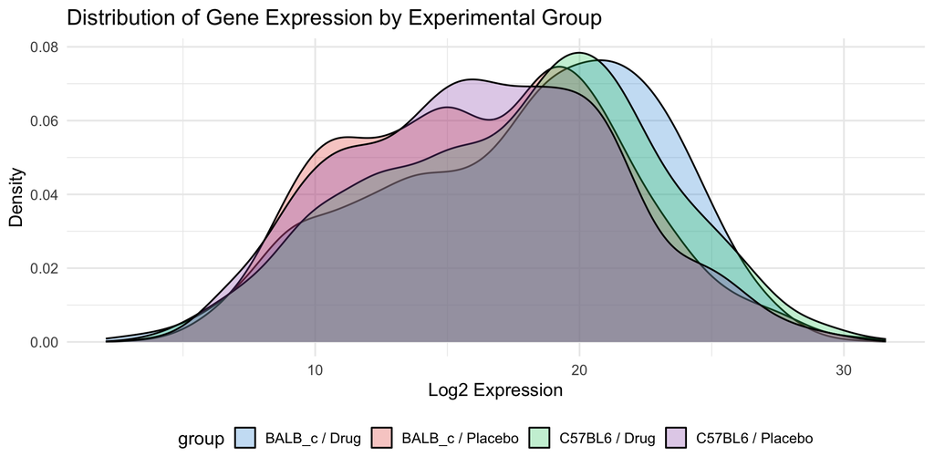

**Code**

```r
# Identify gene columns
gene_cols <- colnames(inflam)[4:ncol(inflam)]
gene_matrix <- as.matrix(inflam[, gene_cols])

# Long format for plotting
inflam_long <- inflam |>
  pivot_longer(cols = all_of(gene_cols),
               names_to = "gene", values_to = "expression") |>
  mutate(group = paste(strain, treatment, sep = " / "))

# Density plot by group
ggplot(inflam_long, aes(x = expression, fill = group)) +
  geom_density(alpha = 0.3) +
  labs(x = "Log2 Expression", y = "Density",
       title = "Gene Expression Distribution by Group")
```

**Interpretation**

The density plot shows the overall distribution of gene expression values across all 100 genes for each experimental group. The Drug and Placebo groups show different distributions — the drug shifts expression of many genes — while strain differences are subtler. This is exactly what we’ll see reflected in PCA: the drug effect will dominate PC1, and strain will appear on PC2.

# Principal Component Analysis (PCA)

## What is PCA?

**Principal Component Analysis** is the most widely used dimensionality reduction method. It transforms a set of correlated variables into a smaller set of uncorrelated variables called **principal components**, ordered by the amount of variance they explain.

**Key concepts:**

- **Principal components** are new axes that maximize variance in the data
- **Eigenvalues** quantify the variance explained by each PC
- **Loadings** describe how much each original variable contributes to each PC
- **Scores** are the coordinates of each observation in the new PC space

**Tip**

PCA requires **continuous** variables. It works best when relationships between variables are approximately **linear**. Always **center** (and usually **scale**) your data before PCA.

## PCA Finds Axes That Maximize Variance

[figure not shown]

## SVD and PCA: Step by Step

**Equations**

**Step 1: Center (and optionally scale) the data**

$$\tilde{X} = \frac{X - \bar{X}}{s_X}$$

**Step 2: Compute the covariance (or correlation) matrix**

$$\Sigma = \frac{1}{n-1} \tilde{X}^T \tilde{X}$$

**Step 3: Eigendecomposition** (or equivalently, SVD of $\tilde{X}$)

$$\tilde{X} = U \cdot \Sigma_s \cdot V^T$$

**Step 4: Extract results**

- **PC scores** = $U \cdot \Sigma_s$ (or equivalently $\tilde{X} \cdot V$)
- **Loadings** = columns of $V$
- **Variance explained** by PC $i$ = $\sigma_i^2 / \sum \sigma_j^2$

**LaTeX**

```
\tilde{X} = \frac{X - \bar{X}}{s_X}

\Sigma = \frac{1}{n-1} \tilde{X}^T \tilde{X}

\tilde{X} = U \cdot \Sigma_s \cdot V^T

\text{Scores} = U \cdot \Sigma_s
\text{Loadings} = V
\text{Var explained}_i = \sigma_i^2 / \sum_j \sigma_j^2
```

**Interpretation**

**What SVD does for PCA:**

- The singular value decomposition factorizes the centered data matrix into three matrices.
- The right singular vectors ($V$) are the PC directions (loadings) — the axes along which variance is maximized.
- The singular values ($\sigma_i$) are proportional to the standard deviation explained by each PC.
- The left singular vectors ($U$), scaled by the singular values, give the PC scores — each observation’s position in the reduced space.

**Why SVD rather than eigendecomposition directly?** SVD is numerically more stable, especially for wide datasets (more variables than observations), which is common in genomics and bioengineering.

## Choosing center vs. scale

| Setting | When to Use | Effect |
| --- | --- | --- |
| `center = TRUE, scale. = FALSE` | Variables in same units | PCA on covariance matrix |
| `center = TRUE, scale. = TRUE` | Variables in different units | PCA on correlation matrix |

**Important**

If your variables are on different scales (e.g., gene expression in log₂ vs. protein concentration in ng/mL), always use `scale. = TRUE`. Otherwise, variables with larger absolute values will dominate the PCA. For our gene expression dataset, all genes are on the same log₂ scale, but we’ll still scale to give each gene equal weight.

# PCA in Practice

## Running PCA with prcomp()

**Output**

```
Importance of components:
                         PC1     PC2     PC3     PC4     PC5     PC6     PC7
Standard deviation     8.192 2.90464 1.94753 1.89621 1.70531 1.57404 1.29326
Proportion of Variance 0.671 0.08437 0.03793 0.03596 0.02908 0.02478 0.01673
Cumulative Proportion  0.671 0.75542 0.79334 0.82930 0.85838 0.88316 0.89988
                           PC8     PC9    PC10    PC11    PC12   PC13    PC14
Standard deviation     1.22717 1.12167 0.93109 0.83233 0.67387 0.6705 0.65048
Proportion of Variance 0.01506 0.01258 0.00867 0.00693 0.00454 0.0045 0.00423
Cumulative Proportion  0.91494 0.92752 0.93619 0.94312 0.94766 0.9522 0.95639
                          PC15    PC16    PC17    PC18    PC19    PC20    PC21
Standard deviation     0.61204 0.59331 0.55473 0.50796 0.48112 0.45994 0.43177
Proportion of Variance 0.00375 0.00352 0.00308 0.00258 0.00231 0.00212 0.00186
Cumulative Proportion  0.96013 0.96365 0.96673 0.96931 0.97163 0.97374 0.97561
                          PC22    PC23   PC24    PC25    PC26   PC27    PC28
Standard deviation     0.41985 0.40789 0.4005 0.37709 0.35760 0.3462 0.33897
Proportion of Variance 0.00176 0.00166 0.0016 0.00142 0.00128 0.0012 0.00115
Cumulative Proportion  0.97737 0.97903 0.9806 0.98206 0.98334 0.9845 0.98568
                          PC29    PC30   PC31    PC32    PC33    PC34    PC35
Standard deviation     0.31459 0.30465 0.2999 0.28642 0.27791 0.25597 0.24326
Proportion of Variance 0.00099 0.00093 0.0009 0.00082 0.00077 0.00066 0.00059
Cumulative Proportion  0.98667 0.98760 0.9885 0.98932 0.99009 0.99075 0.99134
                          PC36    PC37    PC38    PC39    PC40    PC41   PC42
Standard deviation     0.24001 0.23397 0.23075 0.22715 0.20863 0.20493 0.2003
Proportion of Variance 0.00058 0.00055 0.00053 0.00052 0.00044 0.00042 0.0004
Cumulative Proportion  0.99192 0.99246 0.99300 0.99351 0.99395 0.99437 0.9948
                          PC43    PC44    PC45    PC46   PC47    PC48    PC49
Standard deviation     0.19730 0.19180 0.18552 0.17816 0.1746 0.16760 0.16367
Proportion of Variance 0.00039 0.00037 0.00034 0.00032 0.0003 0.00028 0.00027
Cumulative Proportion  0.99516 0.99553 0.99587 0.99619 0.9965 0.99677 0.99704
                          PC50    PC51    PC52    PC53    PC54    PC55    PC56
Standard deviation     0.15820 0.15329 0.14653 0.14442 0.13947 0.13072 0.12832
Proportion of Variance 0.00025 0.00023 0.00021 0.00021 0.00019 0.00017 0.00016
Cumulative Proportion  0.99729 0.99753 0.99774 0.99795 0.99814 0.99832 0.99848
                          PC57    PC58    PC59    PC60    PC61   PC62    PC63
Standard deviation     0.11967 0.11911 0.11281 0.10811 0.10306 0.1020 0.09442
Proportion of Variance 0.00014 0.00014 0.00013 0.00012 0.00011 0.0001 0.00009
Cumulative Proportion  0.99862 0.99877 0.99889 0.99901 0.99912 0.9992 0.99931
                          PC64    PC65    PC66    PC67    PC68    PC69    PC70
Standard deviation     0.09179 0.08924 0.08608 0.08252 0.07868 0.07484 0.07179
Proportion of Variance 0.00008 0.00008 0.00007 0.00007 0.00006 0.00006 0.00005
Cumulative Proportion  0.99939 0.99947 0.99955 0.99961 0.99968 0.99973 0.99978
                          PC71    PC72    PC73    PC74    PC75    PC76    PC77
Standard deviation     0.06510 0.05939 0.05691 0.05255 0.04620 0.04494 0.04069
Proportion of Variance 0.00004 0.00004 0.00003 0.00003 0.00002 0.00002 0.00002
Cumulative Proportion  0.99983 0.99986 0.99989 0.99992 0.99994 0.99996 0.99998
                          PC78    PC79      PC80
Standard deviation     0.03283 0.03011 3.638e-15
Proportion of Variance 0.00001 0.00001 0.000e+00
Cumulative Proportion  0.99999 1.00000 1.000e+00
```

**Code**

```r
# Run PCA on gene expression matrix
# center = TRUE: subtract column means
# scale. = TRUE: divide by column SDs (use correlation matrix)
pca_result <- prcomp(inflam[, gene_cols], center = TRUE, scale. = TRUE)

# Summary shows variance explained by each PC
summary(pca_result)
```

**Interpretation**

The `prcomp()` function performs PCA via SVD. The summary shows that **PC1 captures the majority of total variance** — this is the drug effect. **PC2** captures the next largest share — corresponding to the strain difference. Together, the first two or three PCs capture most of the meaningful variation in 100 genes, while remaining PCs reflect individual mouse-to-mouse biological variation and noise.

## What’s Inside the PCA Object?

**Output**

```
Components of prcomp() output:
```

```
$sdev    - Standard deviations of each PC
```

```
  First 5: 8.192 2.905 1.948 1.896 1.705
```

```
$rotation - Loading matrix (variables x PCs)
```

```
  Dimensions: 100 x 80
```

```
  First 3 genes, first 3 PCs:
```

```
       PC1    PC2     PC3
IL1 0.1190 0.0309 -0.0141
IL2 0.1143 0.0617 -0.0150
IL3 0.1172 0.0292 -0.0164
```

```
$x       - Score matrix (observations x PCs)
```

```
  Dimensions: 80 x 80
```

```
  First 3 mice, first 3 PCs:
```

```
       PC1   PC2    PC3
[1,] 8.604 3.702  2.524
[2,] 8.187 2.983 -0.438
[3,] 7.675 1.697 -1.292
```

```
$center  - Column means used for centering
```

```
$scale   - Column SDs used for scaling
```

**Code**

```r
# The prcomp object contains:
str(pca_result)

# $sdev: standard deviation of each PC
# Eigenvalues = sdev^2
eigenvalues <- pca_result$sdev^2
head(eigenvalues)

# $rotation: loading matrix (100 genes x 80 PCs)
# Each column = one PC's loadings
dim(pca_result$rotation)
pca_result$rotation[1:5, 1:3]  # First 5 genes, first 3 PCs

# $x: score matrix (80 mice x 80 PCs)
# Each row = one mouse's coordinates in PC space
dim(pca_result$x)
pca_result$x[1:5, 1:3]  # First 5 mice, first 3 PCs

# $center and $scale: the centering and scaling values
head(pca_result$center)
head(pca_result$scale)
```

**Interpretation**

**`$sdev`** — The standard deviations along each PC axis. Squaring these gives eigenvalues. The ratio of each eigenvalue to the total tells you the proportion of variance explained.

**`$rotation`** — The loading matrix (also called eigenvectors). Each column is a PC direction in gene space. Large positive or negative values indicate genes that strongly contribute to that PC.

**`$x`** — The score matrix. Each row positions one mouse in the reduced PC coordinate system. These are the values you plot in a PCA scatter plot.

**`$center`** and **`$scale`** — The mean and standard deviation of each gene, used to standardize the data before decomposition. Needed if you want to project new data into the same PC space.

## Scree Plot

**Output**

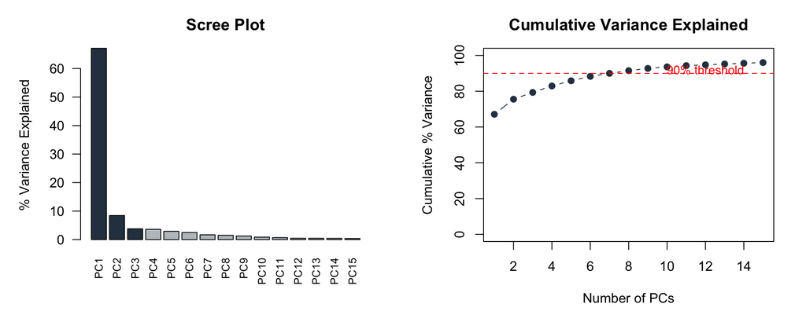

**Code**

```r
# Proportion of variance explained
var_explained <- pca_result$sdev^2 / sum(pca_result$sdev^2)

# Scree plot
barplot(var_explained[1:15] * 100,
        names.arg = paste0("PC", 1:15),
        ylab = "% Variance Explained",
        main = "Scree Plot")

# Cumulative variance
plot(cumsum(var_explained[1:15]) * 100, type = "b",
     xlab = "Number of PCs",
     ylab = "Cumulative % Variance")
abline(h = 90, lty = 2, col = "red")
```

**Interpretation**

The scree plot shows the dominance of PC1, which captures the largest share of variance by far — the drug treatment effect. PC2 adds the strain effect. After PC3, additional PCs each contribute only a small percentage — this is the “elbow” of the scree plot. The cumulative plot shows how many PCs are needed to explain a target amount of variance (the dashed red line marks 90%). Notice that PC3 and beyond capture real biological variation among individual mice, but this variation is not structured by our experimental factors — it reflects the natural heterogeneity of living organisms.

## PCA Score Plots: Multiple PC Combinations

**Output**

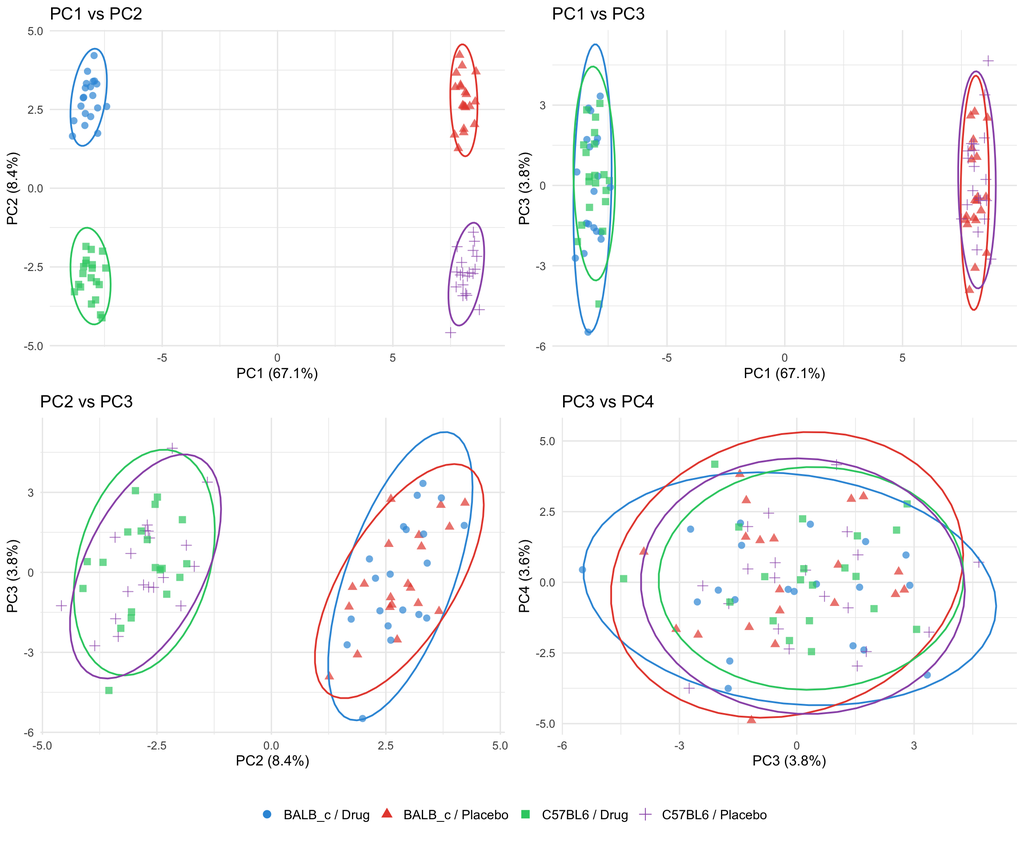

**Code**

```r
# Extract scores and add metadata
pca_scores <- as.data.frame(pca_result$x)
pca_scores$strain <- inflam$strain
pca_scores$treatment <- inflam$treatment
pca_scores$group <- paste(inflam$strain, inflam$treatment, sep = " / ")
var_pct <- round(var_explained * 100, 1)

# Four-panel PCA: different PC combinations
par(mfrow = c(2, 2), mar = c(5, 5, 3, 1))
group_colors <- c("#3498db", "#e74c3c", "#2ecc71", "#9b59b6")
gf <- factor(pca_scores$group)

# PC1 vs PC2
plot(pca_scores$PC1, pca_scores$PC2, col = group_colors[gf], pch = 19,
     xlab = paste0("PC1 (", var_pct[1], "%)"),
     ylab = paste0("PC2 (", var_pct[2], "%)"), main = "PC1 vs PC2")

# PC1 vs PC3
plot(pca_scores$PC1, pca_scores$PC3, col = group_colors[gf], pch = 19,
     xlab = paste0("PC1 (", var_pct[1], "%)"),
     ylab = paste0("PC3 (", var_pct[3], "%)"), main = "PC1 vs PC3")

# PC2 vs PC3
plot(pca_scores$PC2, pca_scores$PC3, col = group_colors[gf], pch = 19,
     xlab = paste0("PC2 (", var_pct[2], "%)"),
     ylab = paste0("PC3 (", var_pct[3], "%)"), main = "PC2 vs PC3")

# PC3 vs PC4
plot(pca_scores$PC3, pca_scores$PC4, col = group_colors[gf], pch = 19,
     xlab = paste0("PC3 (", var_pct[3], "%)"),
     ylab = paste0("PC4 (", var_pct[4], "%)"), main = "PC3 vs PC4")
legend("topright", levels(gf), col = group_colors, pch = 19, cex = 0.7)
```

**Interpretation**

**PC1 vs PC2** shows the two main biological effects: PC1 (x-axis) separates Drug from Placebo, and PC2 (y-axis) separates the two mouse strains within each treatment group. These first two PCs capture the experimental design, but notice the within-group scatter — individual mice show real biological variation in their gene expression responses.

**PC1 vs PC3** still shows clear treatment separation along the x-axis, but on the y-axis (PC3), the four groups overlap completely. PC3 captures biological variation *among individual mice* that is unrelated to either treatment or strain — perhaps differences in age, immune history, or housing conditions.

**PC2 vs PC3** reveals the strain separation along the x-axis (PC2), but both axes show much more overlap than PC1 vs PC2. This highlights a key principle: each successive PC captures less structured variation and more noise.

**PC3 vs PC4** shows no group separation at all — the four groups are completely intermixed. These lower PCs capture individual mouse-to-mouse variation and measurement noise. This is exactly why we use dimensionality reduction: the important biological signal is concentrated in the first few PCs, and the remaining variation is uninformative for our experimental question.

## PCA Loadings: Which Genes Drive Each PC?

**Output**

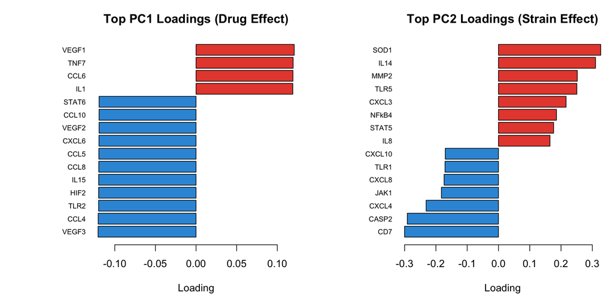

**Code**

```r
# Extract loadings
loadings_df <- data.frame(
  gene = rownames(pca_result$rotation),
  PC1 = pca_result$rotation[, 1],
  PC2 = pca_result$rotation[, 2]
)

# Top genes contributing to PC1
loadings_df |> arrange(desc(abs(PC1))) |> head(15)

# Top genes contributing to PC2
loadings_df |> arrange(desc(abs(PC2))) |> head(15)

# Heatmap of loadings for top genes
top_genes <- unique(c(
  head(loadings_df$gene[order(abs(loadings_df$PC1), decreasing = TRUE)], 20),
  head(loadings_df$gene[order(abs(loadings_df$PC2), decreasing = TRUE)], 20)
))
heatmap(pca_result$rotation[top_genes, 1:5], scale = "none",
        col = hcl.colors(50, "RdBu"), main = "Loadings Heatmap")
```

**Interpretation**

**PC1 loadings** identify the genes most affected by the anti-inflammatory drug. Genes with large positive loadings are upregulated in Placebo (high inflammation), while genes with large negative loadings are upregulated with Drug treatment (reduced inflammation). These are the genes most responsive to treatment.

**PC2 loadings** identify genes that differ between mouse strains regardless of treatment. These reflect inherent immunological differences between BALB/c and C57BL/6 mice.

The loadings are essentially the “recipe” for each PC — they tell you how to weight each gene to create that component. This makes PCA **interpretable** in a way that t-SNE and UMAP are not.

## PCA Biplot

**Output**

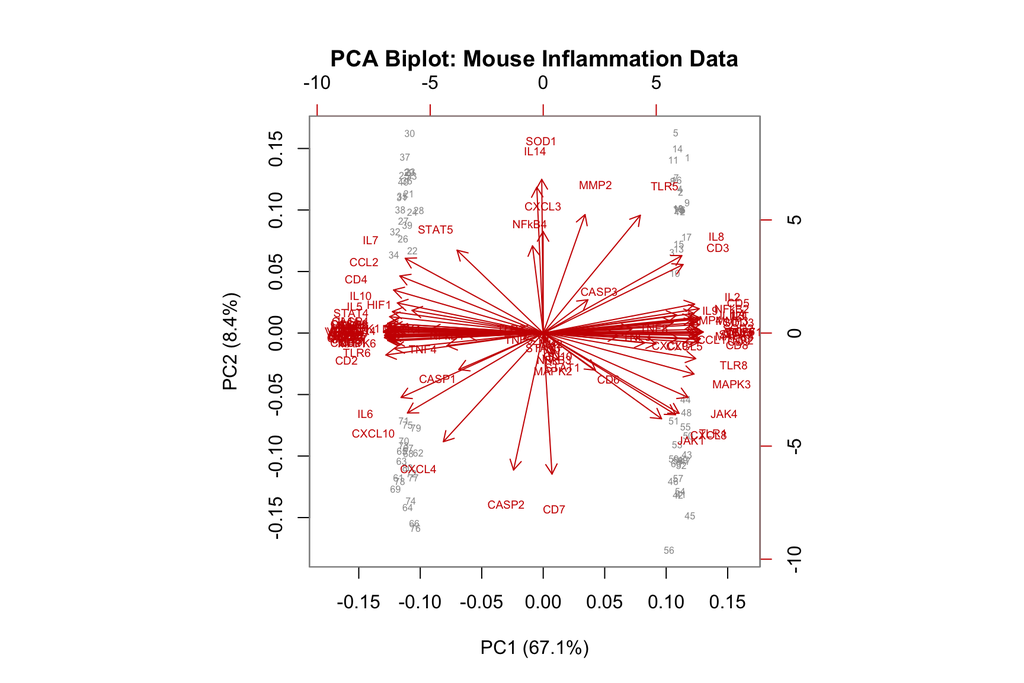

**Code**

```r
# Biplot: samples as points, variables as arrows
biplot(pca_result, col = c("gray60", "red3"), cex = c(0.5, 0.6),
       xlab = paste0("PC1 (", var_pct[1], "%)"),
       ylab = paste0("PC2 (", var_pct[2], "%)"),
       main = "PCA Biplot")
```

**Interpretation**

The biplot overlays both the **sample scores** (gray points) and the **variable loadings** (red arrows) in the same space. Arrows pointing in the same direction indicate correlated genes. Arrows pointing in opposite directions indicate negatively correlated genes. The length and direction of each arrow shows how strongly and in which direction that gene contributes to the PCA space. With 100 genes, the biplot is dense — the loadings bar plots are often more informative for high-dimensional data.

# PCoA and NMDS

## Why Distance-Based Ordination?

PCA operates directly on the data matrix and assumes linear relationships. But in many bioengineering contexts, we need more flexibility:

**When PCA is not ideal:**

- **Count data** (species abundances, gene counts) — Euclidean distance on raw counts overweights abundant species
- **Compositional data** (relative abundances, proportions) — standard distances don’t account for the constraint that proportions sum to 1
- **Presence/absence data** — Euclidean distance treats shared absences as similarity
- **Mixed data types** — some variables continuous, others categorical or ordinal

**Distance-based methods** let you choose a dissimilarity metric tailored to your data type, then ordinate based on that metric. This separates the “how do I measure similarity?” question from the “how do I visualize it?” question.

## Data → Correlation and Distance Matrices

**Data Matrix** (Objects × Variables)

|  | 1 | 2 | 3 |
| --- | --- | --- | --- |
| 1 | $y_{11}$ | $y_{12}$ | $y_{13}$ |
| 2 | $y_{21}$ | $y_{22}$ | $y_{23}$ |
| 3 | $y_{31}$ | $y_{32}$ | $y_{33}$ |

**→ Correlation Matrix** (Variables × Variables)

|  | 1 | 2 | 3 |
| --- | --- | --- | --- |
| 1 | 1 | $r_{12}$ | $r_{13}$ |
| 2 | $r_{21}$ | 1 | $r_{23}$ |
| 3 | $r_{31}$ | $r_{32}$ | 1 |

**→ Distance Matrix** (Objects × Objects)

|  | 1 | 2 | 3 |
| --- | --- | --- | --- |
| 1 | 0 | $d_{12}$ | $d_{13}$ |
| 2 | $d_{21}$ | 0 | $d_{23}$ |
| 3 | $d_{31}$ | $d_{32}$ | 0 |

- **Correlation matrix** → used for PCA, factor analysis (relationships among *variables*)
- **Distance matrix** → used for PCoA, NMDS, clustering (relationships among *objects*)

## Dissimilarity / Distance Formulas

| Dissimilarity | Equation |
| --- | --- |
| **Euclidean** | $\sqrt{\displaystyle\sum_{j=1}^{p}(y_{1j} - y_{2j})^2}$ |
| **Manhattan** | $\displaystyle\sum_{j=1}^{p}\lvert y_{1j} - y_{2j}\rvert$ |
| **Bray–Curtis** | $\dfrac{\displaystyle\sum_{j=1}^{p}\lvert y_{1j} - y_{2j}\rvert}{\displaystyle\sum_{j=1}^{p}(y_{1j} + y_{2j})}$ |
| **Canberra** | $\dfrac{1}{p}\displaystyle\sum_{j=1}^{p}\dfrac{\lvert y_{1j} - y_{2j}\rvert}{y_{1j} + y_{2j}}$ |

**Tip**

**Euclidean** is the default for continuous data. **Bray-Curtis** is standard for count/compositional data (ecology, microbiome). Always choose a distance metric that matches your data type and scientific question.

## PCoA — Principal Coordinates Analysis

PCoA (also called **classical multidimensional scaling**) takes a distance matrix as input and finds coordinates in reduced space that best preserve those distances.

**When to use PCoA:**

- Microbiome data → Bray-Curtis or UniFrac distances
- Community ecology → Jaccard distances for presence/absence
- Biomaterial surface properties → custom dissimilarity measures
- Any data where you want metric ordination with a specific distance metric
- When you need scores for downstream linear models (unlike NMDS)

## PCoA on Inflammation Data

**Output**

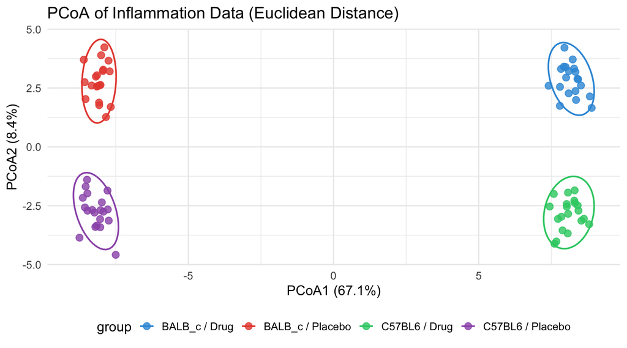

**Code**

```r
# Step 1: Compute distance matrix
dist_euc <- dist(scale(inflam[, gene_cols]), method = "euclidean")

# Step 2: Run PCoA
pcoa_res <- cmdscale(dist_euc, k = 2, eig = TRUE)

# Step 3: Calculate variance explained
pcoa_var <- round(100 * pcoa_res$eig[1:2] / sum(abs(pcoa_res$eig)), 1)

# Step 4: Plot
pcoa_df <- data.frame(
  PCoA1 = pcoa_res$points[, 1],
  PCoA2 = pcoa_res$points[, 2],
  group = paste(inflam$strain, inflam$treatment, sep = " / ")
)

ggplot(pcoa_df, aes(x = PCoA1, y = PCoA2, color = group)) +
  geom_point(size = 3) +
  stat_ellipse(level = 0.95) +
  labs(x = paste0("PCoA1 (", pcoa_var[1], "%)"),
       y = paste0("PCoA2 (", pcoa_var[2], "%)"))
```

**Interpretation**

- With Euclidean distance on scaled data, PCoA gives results identical to PCA — this is expected because PCA on the correlation matrix is mathematically equivalent to PCoA with Euclidean distance on standardized data.
- The advantage of PCoA is that you can swap in any distance metric: Bray-Curtis for compositional data, Manhattan for count data, or custom metrics for domain-specific applications.

## NMDS — Non-metric Multidimensional Scaling

**NMDS** relaxes PCoA’s requirement to preserve exact distances. Instead, it preserves only the **rank order** of dissimilarities — if sample A is more similar to sample B than to sample C in the original space, NMDS ensures this ordering is maintained in the reduced space.

**When to use NMDS over PCoA:**

- Ecological community data where exact distances are less meaningful than relative rankings
- When you suspect non-linear relationships between samples
- When the data don’t produce good PCoA results (negative eigenvalues in PCoA can indicate problems)

**Warning**

NMDS scores preserve only rank-order relationships. They should **not** be used as predictors in regression or ANOVA! Use PCoA scores instead if you need downstream statistical modeling.

## NMDS on Inflammation Data

**Output**

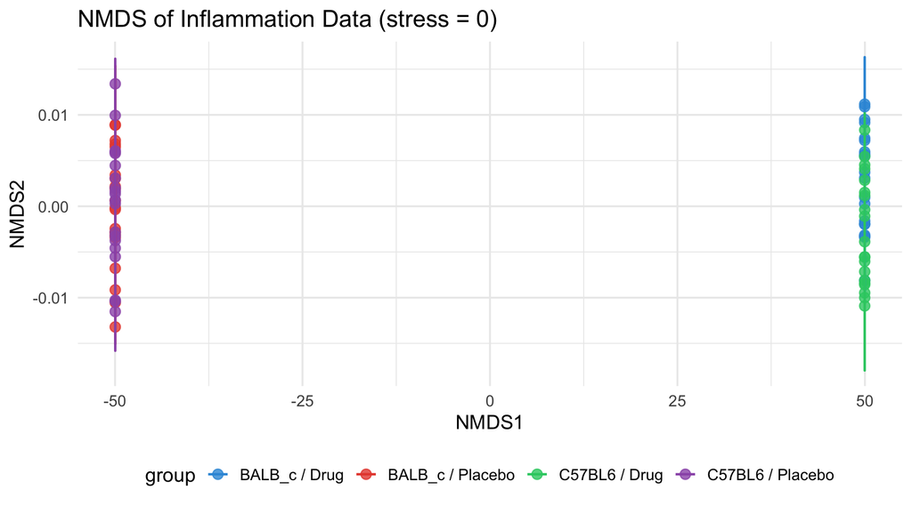

**Code**

```r
library(vegan)

# Run NMDS
set.seed(2026)
nmds_res <- metaMDS(inflam[, gene_cols], distance = "euclidean",
                     k = 2, trace = FALSE, autotransform = FALSE)

# Check stress (< 0.1 is good)
cat("Stress:", nmds_res$stress, "\n")

# Plot
nmds_df <- data.frame(
  NMDS1 = nmds_res$points[, 1],
  NMDS2 = nmds_res$points[, 2],
  group = paste(inflam$strain, inflam$treatment, sep = " / ")
)

ggplot(nmds_df, aes(x = NMDS1, y = NMDS2, color = group)) +
  geom_point(size = 3) +
  stat_ellipse(level = 0.95)
```

**Interpretation**

- The NMDS ordination shows some of the same basic pattern as PCA and PCoA: clear separation by drug treatment along one axis, but much less strain separation along the other.
- The **stress value** quantifies how well the 2D ordination preserves the original distance ranks — values below 0.1 indicate a good fit. - Note that NMDS axes don’t have “% variance explained” labels because they preserve rank order, not variance.

## PERMANOVA: Testing Multivariate Group Differences

**Output**

```
Permutation test for adonis under reduced model
Permutation: free
Number of permutations: 999

adonis2(formula = dist_mat ~ treatment * strain, data = inflam, permutations = 999)
         Df SumOfSqs      R2      F Pr(>F)
Model     3   5988.5 0.75803 79.365  0.001 ***
Residual 76   1911.5 0.24197
Total    79   7900.0 1.00000
---
Signif. codes:  0 '***' 0.001 '**' 0.01 '*' 0.05 '.' 0.1 ' ' 1
```

**Code**

```r
library(vegan)

# Distance matrix
dist_mat <- dist(scale(inflam[, gene_cols]))

# PERMANOVA: test treatment, strain, and interaction effects
perm_result <- adonis2(dist_mat ~ treatment * strain,
                        data = inflam, permutations = 999)
print(perm_result)

# Check homogeneity of dispersions
disp_trt <- betadisper(dist_mat, inflam$treatment)
permutest(disp_trt, permutations = 999)
```

[output not shown]

## PCA vs PCoA vs NMDS

| Aspect | PCA | PCoA | NMDS |
| --- | --- | --- | --- |
| **Input** | Covariance/Correlation | Distance matrix | Distance matrix |
| **Scaling** | Metric | Metric | Non-metric (ordinal) |
| **Distance** | Euclidean only | Any metric | Any metric |
| **Variance explained** | Yes (per PC) | Yes (per axis) | No (stress only) |
| **Downstream models** | Yes | Yes | No |
| **Best for** | Continuous data, linear | Any distance metric | Ecological data, non-linear |

# t-SNE and UMAP

## Why Beyond PCA?

PCA finds **linear** axes of maximum variance. This works beautifully when group differences are large and approximately linear (as in our drug effect). But biological data often contains:

- **Non-linear manifolds** — cell types that lie on curved surfaces in gene space
- **Complex local structure** — subclusters within groups that PCA flattens
- **Hierarchical organization** — groups within groups (e.g., T-cell subtypes within the T-cell cluster)

**t-SNE** and **UMAP** are designed to reveal this local structure by focusing on preserving neighborhood relationships rather than global distances.

**Important**

t-SNE and UMAP are **visualization** tools, not analysis tools. Distances between clusters are NOT meaningful. Always use PCA first for quantitative analysis, then t-SNE/UMAP for visualization.

## The Core Idea: Neighborhood Graphs

Both t-SNE and UMAP share the same underlying philosophy, which is fundamentally different from PCA:

**PCA asks:** “What linear projection preserves the most variance?”

**t-SNE and UMAP ask:** “Which points are neighbors in high-dimensional space, and can we arrange points in 2D so that those neighborhood relationships are preserved?”

The key steps are:

1. **Model neighborhoods in high-D** — For each data point, determine which other points are its “neighbors” and how similar they are
2. **Initialize a low-D layout** — Place all points in 2D (randomly or via PCA)
3. **Optimize** — Iteratively move points in 2D until the low-D neighborhood structure matches the high-D neighborhood structure as closely as possible

The methods differ in *how* they define neighborhoods, *what* they optimize, and *how* they handle the mismatch between high-D and low-D space.

## SNE: Stochastic Neighbor Embedding

**SNE** (Hinton & Roweis, 2002) introduced the probability-based approach to dimensionality reduction. For each pair of points, SNE defines a probability that reflects their similarity:

**In high-dimensional space:** The probability that point $x_j$ is a neighbor of point $x_i$ follows a Gaussian:

$$p_{j|i} = \frac{\exp(-||x_i - x_j||^2 / 2\sigma_i^2)}{\sum_{k \neq i} \exp(-||x_i - x_k||^2 / 2\sigma_i^2)}$$

Each point $x_i$ gets its own $\sigma_i$, set so that the effective number of neighbors matches the user-specified **perplexity** — a smooth measure of neighborhood size.

**In low-dimensional space:** The same formula is applied to the 2D coordinates $y_i$, giving probabilities $q_{j|i}$.

**Optimization:** SNE minimizes the **KL divergence** between P and Q — a measure of how different the two probability distributions are — by moving the 2D points via gradient descent.

## From SNE to t-SNE: Solving the Crowding Problem

[figure not shown]

## The Crowding Problem and the t-Distribution Solution

Original SNE uses Gaussians in *both* high-D and low-D. This creates a fundamental problem:

**The crowding problem:** In high dimensions, a point can have many moderately distant neighbors — there is a lot of “room” in high-D space. When you try to place all those neighbors equally close in 2D, there is simply not enough area. Moderately distant points are forced to collapse on top of nearby points.

**van der Maaten & Hinton (2008) fixed this** with two changes:

1. **Student’s t-distribution (df = 1)** for the low-D similarities instead of Gaussian. The t-distribution has **heavier tails**, meaning moderately distant points in high-D are allowed to be much farther apart in low-D. This provides the “pressure” to push dissimilar points apart and create the clean cluster separations t-SNE is known for.
2. **Symmetrized probabilities:** Instead of separate conditional probabilities $p_{j|i}$ and $p_{i|j}$, t-SNE uses a single joint probability $p_{ij} = (p_{j|i} + p_{i|j}) / 2n$, which simplifies the gradient and improves optimization.

**Note**

The “t” in t-SNE refers to the Student’s t-distribution — the same distribution we use for t-tests! Here it serves a completely different purpose: its heavy tails allow the algorithm to faithfully embed local structure while giving distant points room to spread out.

## How t-SNE Uses Perplexity

- The **perplexity** parameter controls the Gaussian bandwidth $\sigma_i$ for each point, effectively setting the size of each point’s neighborhood:
- **Low perplexity (5–10):** Each point considers only its very closest neighbors. The algorithm focuses on fine-grained local structure, potentially breaking real clusters into subclusters.
- **High perplexity (25+):** Each point considers many neighbors. Broader patterns emerge, but local detail may be lost. Perplexity must be less than $n/3$.
- In practice, perplexity acts like a soft version of “k” in k-nearest neighbors — it controls how many points each observation “cares about” when constructing its probability distribution.

## t-SNE on Inflammation Data

**Output**

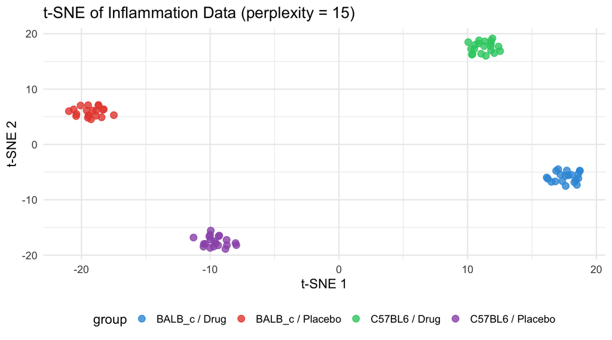

**Code**

```r
library(Rtsne)

set.seed(2026)
tsne_res <- Rtsne(as.matrix(inflam[, gene_cols]),
                   perplexity = 15, dims = 2,
                   verbose = FALSE, check_duplicates = FALSE)

tsne_df <- data.frame(
  tSNE1 = tsne_res$Y[, 1], tSNE2 = tsne_res$Y[, 2],
  group = paste(inflam$strain, inflam$treatment, sep = " / ")
)

ggplot(tsne_df, aes(x = tSNE1, y = tSNE2, color = group)) +
  geom_point(size = 3, alpha = 0.8) +
  labs(x = "t-SNE 1", y = "t-SNE 2",
       title = "t-SNE (perplexity = 15)")
```

**Interpretation**

- t-SNE separates the four experimental groups into visually distinct clusters.
- Unlike PCA, t-SNE axes have no units or “% variance explained.”
- The separation is dramatic, but remember: the distances between clusters are not meaningful — you cannot conclude that BALB/c Drug is “closer to” C57BL/6 Drug based on cluster positions.
- The perplexity parameter (here 15) controls how many neighbors each point considers — smaller values emphasize very local structure, larger values capture broader patterns.

## t-SNE: Perplexity Comparison

**Output**

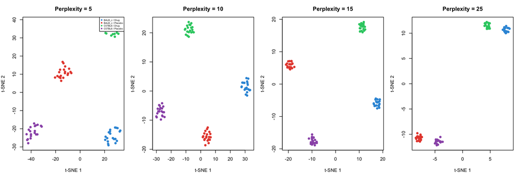

**Code**

```r
# Run t-SNE at multiple perplexity values
for (p in c(5, 10, 15, 25)) {
  set.seed(2026)
  res <- Rtsne(as.matrix(inflam[, gene_cols]), perplexity = p,
               dims = 2, verbose = FALSE, check_duplicates = FALSE)
  plot(res$Y, col = group_factor, pch = 19,
       main = paste("Perplexity =", p))
}
```

**Interpretation**

- The perplexity parameter balances local vs. global structure.
- With our 80-mouse dataset, perplexity must be less than n/3 ≈ 26.
- Perplexity 5 focuses on very local neighborhoods (may over-fragment).
- Perplexity 10–15 gives clean group separation. Perplexity 25 approaches the maximum practical value for this sample size.
- Always try multiple perplexity values — no single setting tells the full story.

# UMAP: From probability distributions to topological spaces

## UMAP: Uniform Manifold Approximation and Projection

UMAP (McInnes, Healy & Melville, 2018) achieves similar goals to t-SNE but approaches the problem from **algebraic topology** rather than information theory. The core assumption is that the data lies on a **manifold** — a curved surface embedded in high-dimensional space — and that the manifold is locally approximately uniform.

**The UMAP pipeline:**

1. **Build a local neighborhood graph** — For each point, find its k nearest neighbors and assign edge weights based on distance. Crucially, each point normalizes distances relative to its *own* nearest neighbor, ensuring points in sparse regions of the data are still connected to their local neighbors.
2. **Create a fuzzy simplicial set** — The local neighborhood graphs from each point are combined into a single global weighted graph using a fuzzy union operation. If point A considers B a neighbor *or* B considers A a neighbor, an edge exists between them (with membership strength $w = a + b - a \cdot b$).
3. **Optimize a low-D layout** — Initialize points in 2D (via spectral embedding or randomly), then use stochastic gradient descent to minimize the **cross-entropy** between the high-D and low-D graph edge weights. Connected points are attracted together; disconnected points are repelled.

## UMAP Algorithm: From Neighborhoods to Embeddings

- The diagram on the next slide walks through UMAP’s three stages.
- Read left to right: first, each point builds a local neighborhood weighted by distance from its nearest neighbor.
- Then, all local views are merged into a single fuzzy weighted graph — edge thickness reflects connection strength.
- Finally, UMAP arranges points in 2D so that the low-D graph’s edge weights match the high-D graph as closely as possible, using stochastic gradient descent on a cross-entropy loss.

**Note**

The key difference from t-SNE is in how neighborhoods are defined. UMAP normalizes distances *locally* — each point’s scale is set by its own nearest-neighbor distance — and combines neighborhoods with a fuzzy union rather than symmetrized conditional probabilities. This local normalization is what allows UMAP to handle data where different regions have very different densities.

## UMAP Algorithm: From Neighborhoods to Embeddings

[figure not shown]

## UMAP’s Key Parameters

**`n_neighbors`** controls how UMAP balances local vs. global structure — analogous to perplexity in t-SNE:

- **Small n_neighbors (5–10):** Very local focus. Captures fine-grained structure but may miss larger-scale patterns. Cluster boundaries may fragment.
- **Large n_neighbors (30–50):** Each point’s neighborhood encompasses more of the dataset. Broader topology is preserved, but small subclusters may merge.

**`min_dist`** controls the minimum distance between points in the embedding:

- **Small min_dist (0.0–0.1):** Points pack tightly into clusters with clear gaps between them. Good for identifying discrete groups.
- **Large min_dist (0.5–1.0):** Points spread out more uniformly. Better for visualizing continuous variation and gradients within groups.

**Tip**

Start with `n_neighbors = 15` and `min_dist = 0.1` as defaults, then explore. Unlike perplexity in t-SNE, `n_neighbors` doesn’t have a strict upper bound relative to n, though very large values lose the “local” character of UMAP.

## t-SNE vs. UMAP: Shared Philosophy, Different Mathematics

[figure not shown]

## Key Differences Between t-SNE and UMAP

Despite the similarities, three differences matter in practice:

**1. Speed and scalability:** UMAP uses stochastic gradient descent with negative sampling, giving it approximately O(n) time per epoch versus t-SNE’s O(n log n) with Barnes-Hut approximation. For datasets above ~50,000 points, UMAP is dramatically faster.

**2. Global structure preservation:** t-SNE’s KL divergence is asymmetric — it heavily penalizes placing true neighbors far apart (good), but barely penalizes placing distant points close together. This means the *relative positions* of clusters in a t-SNE plot are essentially meaningless. UMAP’s cross-entropy loss is symmetric, meaning it also pushes distant points apart, better preserving the global topology. Clusters that are biologically related tend to appear closer together in UMAP than in t-SNE.

**3. Theoretical foundation:** UMAP is grounded in topological data analysis, which provides theoretical justification for why the algorithm works and for the meaning of its parameters. t-SNE is more heuristic — the t-distribution was chosen because it works well, not because it follows from a mathematical theory.

**Note**

For most bioengineering applications, UMAP is now the default choice for non-linear visualization due to its speed and better global structure preservation. t-SNE remains valuable for small datasets where you want to carefully explore local structure at multiple perplexity settings.

## UMAP on Inflammation Data

**Output**

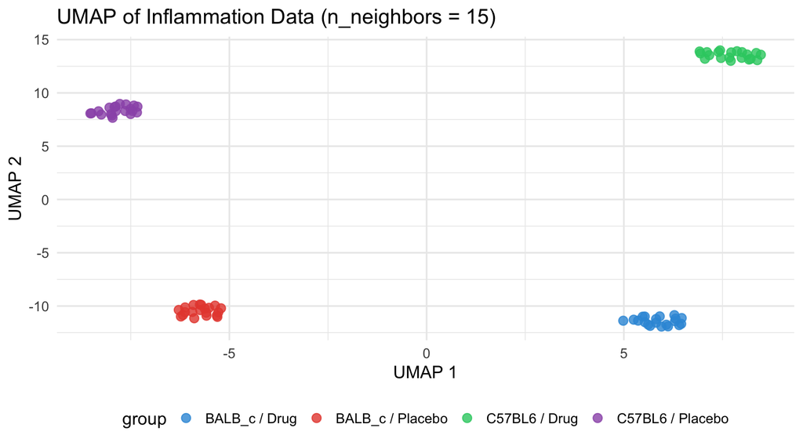

**Code**

```r
library(umap)

umap_config <- umap.defaults
umap_config$n_neighbors <- 15
umap_config$min_dist <- 0.1
umap_config$random_state <- 2026

umap_res <- umap(as.matrix(inflam[, gene_cols]), config = umap_config)

umap_df <- data.frame(
  UMAP1 = umap_res$layout[, 1], UMAP2 = umap_res$layout[, 2],
  group = paste(inflam$strain, inflam$treatment, sep = " / ")
)

ggplot(umap_df, aes(x = UMAP1, y = UMAP2, color = group)) +
  geom_point(size = 3) +
  labs(x = "UMAP 1", y = "UMAP 2")
```

**Interpretation**

UMAP produces clean, well-separated clusters similar to t-SNE, but tends to preserve more of the global topology — the relative positions of clusters may be more consistent across runs. UMAP is also faster than t-SNE, making it the default for large datasets in single-cell genomics.

Key parameters: `n_neighbors` (analogous to perplexity — controls local/global tradeoff) and `min_dist` (controls how tightly points pack together).

## Side-by-Side: PCA vs t-SNE vs UMAP

**Output**

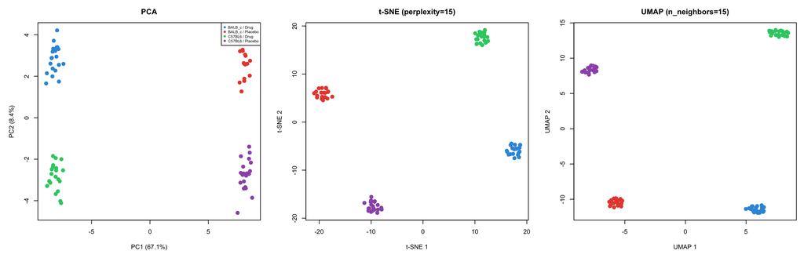

**Code**

```r
par(mfrow = c(1, 3))

# PCA
plot(pca_scores$PC1, pca_scores$PC2, col = group_factor, pch = 19,
     main = "PCA")

# t-SNE
plot(tsne_df$tSNE1, tsne_df$tSNE2, col = group_factor, pch = 19,
     main = "t-SNE")

# UMAP
plot(umap_df$UMAP1, umap_df$UMAP2, col = group_factor, pch = 19,
     main = "UMAP")
```

**Interpretation**

All three methods recover the four experimental groups, but with different characteristics. **PCA** preserves distances and provides interpretable axes with variance-explained labels. Note the within-group scatter — real biological variation among individual mice is visible. **t-SNE** exaggerates cluster separation, making groups appear as distinct islands with tighter internal clustering than PCA suggests. **UMAP** strikes a balance, preserving more global topology than t-SNE while still pulling groups apart.

For this dataset, PCA is the clear winner — the drug and strain effects are well-captured by linear axes. t-SNE and UMAP add visual appeal but no additional biological insight. In datasets with more complex, non-linear structure (many cell types, hierarchical subtypes), t-SNE/UMAP become essential.

## Key Takeaways: Dimensionality Reduction

| Feature | PCA | t-SNE | UMAP |
| --- | --- | --- | --- |
| **Distances meaningful?** | Yes | No | Partially |
| **Global structure** | Preserved | Lost | Mostly preserved |
| **Interpretable axes** | Yes (loadings) | No | No |
| **Deterministic** | Yes | No (set seed!) | No (set seed!) |
| **Speed** | Fast | Slow (O(n²)) | Fast |
| **Best for** | Analysis + preprocessing | Small data visualization | Large data visualization |

**Tip**

**Always run PCA first.** Use it for quantitative analysis and feature selection. Then use UMAP or t-SNE for publication-quality visualization if the linear PCA plot doesn’t tell the whole story.

# Clustering

## Why Clustering?

Dimensionality reduction shows us structure. **Clustering** formalizes that structure by assigning each observation to a group.

**Common bioengineering applications:**

- **Cell type identification** — assigning single cells to populations based on gene expression
- **Patient stratification** — grouping patients by molecular profile for personalized treatment
- **Biomaterial screening** — identifying formulation families with similar performance
- **Quality control** — detecting batch effects or outlier samples
- **Drug response** — classifying responders vs. non-responders

**Key question:** Are there natural groupings in the data, and if so, how many groups are there and which observations belong to which group?

## Overview of Clustering Methods

[figure not shown]

## Choosing a Clustering Method

| Question | K-Means | Hierarchical | KNN |
| --- | --- | --- | --- |
| **Supervised?** | No | No | Yes (needs labels) |
| **Need to specify k?** | Yes, in advance | No, cut tree later | Yes (k neighbors) |
| **Cluster shape** | Spherical | Any shape | Flexible boundaries |
| **Scalability** | Excellent (large n) | Poor (O(n²)) | Moderate |
| **Deterministic?** | No (random init) | Yes | Yes |
| **Output** | Cluster assignments | Dendrogram | Predicted class |

**Note**

**K-Means** and **Hierarchical clustering** are **unsupervised** — they discover groups without using any labels. **KNN** is **supervised** — it requires labeled training data and classifies new observations based on their nearest labeled neighbors.

# Hierarchical Clustering

## What is Hierarchical Clustering?

Creates a tree-like structure (**dendrogram**) of nested clusters by iteratively merging the most similar observations or groups.

**Agglomerative (bottom-up) algorithm:**

1. Start with each observation as its own cluster
2. Find the two closest clusters
3. Merge them into one cluster
4. Repeat until all observations are in one cluster
5. Cut the dendrogram at a chosen height to get k clusters

## Linkage Methods

**Equations**

**Single Linkage (Minimum):**
$$d(C_i, C_j) = \min_{x \in C_i, y \in C_j} d(x, y)$$

**Complete Linkage (Maximum):**
$$d(C_i, C_j) = \max_{x \in C_i, y \in C_j} d(x, y)$$

**Average Linkage:**
$$d(C_i, C_j) = \frac{1}{|C_i||C_j|} \sum_{x \in C_i} \sum_{y \in C_j} d(x, y)$$

**Ward’s Method:** Minimizes within-cluster sum of squares at each step

**LaTeX**

```
d_{single}(C_i, C_j) = \min_{x \in C_i, y \in C_j} d(x, y)
d_{complete}(C_i, C_j) = \max_{x \in C_i, y \in C_j} d(x, y)
d_{average}(C_i, C_j) = \frac{1}{|C_i||C_j|} \sum \sum d(x, y)
```

**Interpretation**

**Single linkage** can create elongated, “chaining” clusters. **Complete linkage** produces compact, roughly spherical clusters. **Average linkage** is a compromise between the two. **Ward’s method** (recommended default) tends to produce balanced, similarly-sized clusters — it is the most common choice for biological data.

## Hierarchical Clustering: Inflammation Data

**Output**

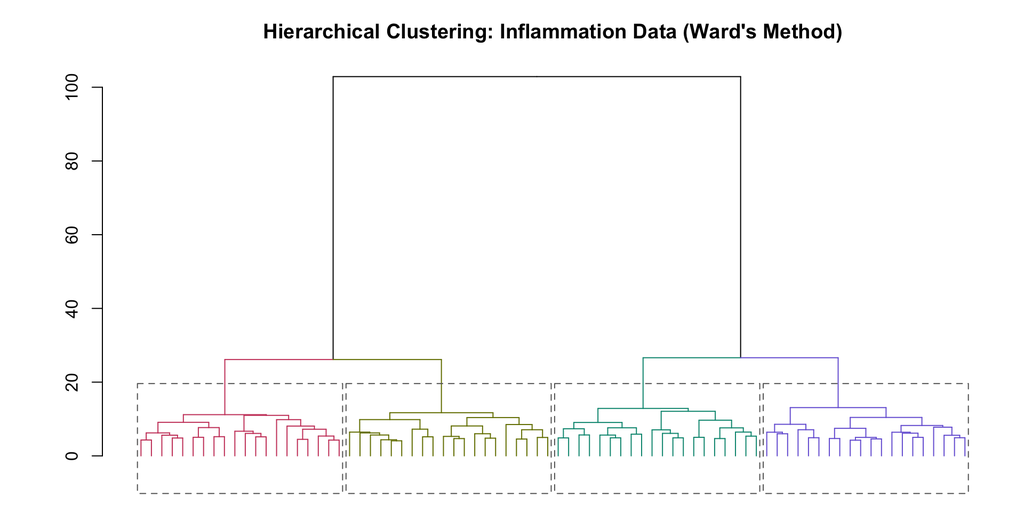

**Code**

```r
# Scale the gene expression data
inflam_scaled <- scale(inflam[, gene_cols])

# Distance matrix
dist_mat_clust <- dist(inflam_scaled)

# Hierarchical clustering with Ward's method
hc_ward <- hclust(dist_mat_clust, method = "ward.D2")

# Enhanced dendrogram
library(dendextend)
dend <- as.dendrogram(hc_ward)
dend <- color_branches(dend, k = 4)
plot(dend, main = "Hierarchical Clustering (Ward's)", leaflab = "none")
rect.dendrogram(dend, k = 4, border = "gray40", lty = 2)

# Cut tree to get 4 clusters
clusters_hc <- cutree(hc_ward, k = 4)
table(clusters_hc, paste(inflam$strain, inflam$treatment))
```

**Interpretation**

The dendrogram shows two major branches corresponding to Drug vs. Placebo, with each branch further splitting by strain. Cutting the tree at k = 4 recovers the four experimental groups almost perfectly. The height at which branches merge reflects the dissimilarity between groups — the Drug/Placebo split occurs at a much greater height than the within-treatment strain split, consistent with the PCA results showing treatment as the dominant axis.

## Cluster Validation: Silhouette Analysis

**Output**

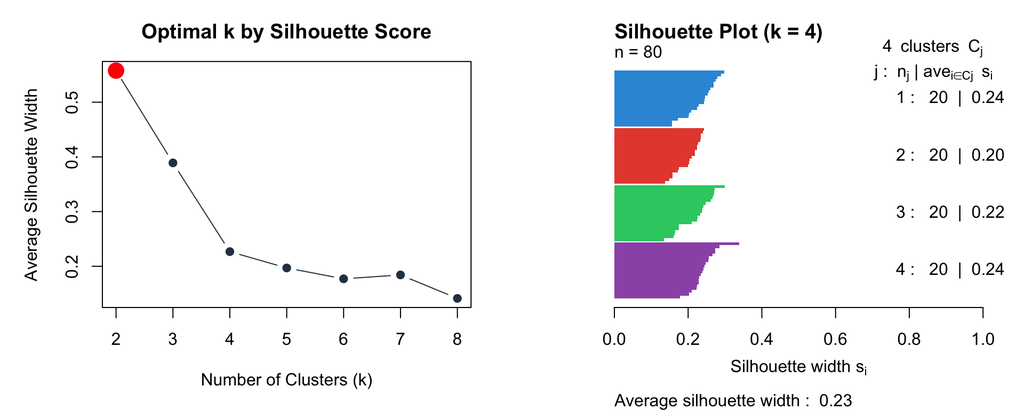

**Code**

```r
library(cluster)

# Test multiple k values
sil_scores <- sapply(2:8, function(k) {
  cl <- cutree(hc_ward, k = k)
  mean(silhouette(cl, dist_mat_clust)[, "sil_width"])
})
plot(2:8, sil_scores, type = "b", pch = 19,
     xlab = "k", ylab = "Avg Silhouette Width")

# Detailed silhouette for chosen k
sil_4 <- silhouette(cutree(hc_ward, k = 4), dist_mat_clust)
plot(sil_4, main = "Silhouette (k = 4)")
```

## Clustered Heatmap

**Output**

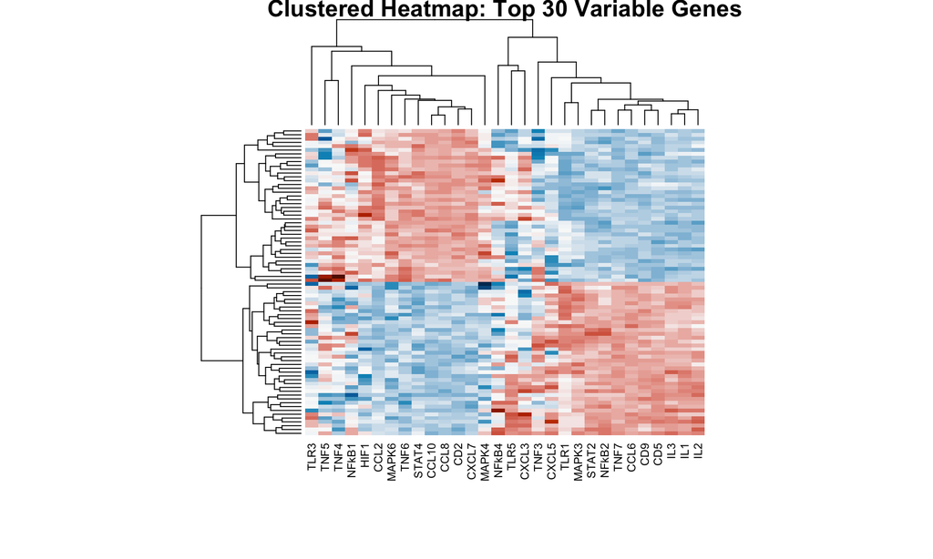

**Code**

```r
# Select top 30 most variable genes
gene_vars <- apply(inflam_scaled, 2, var)
top_30 <- names(sort(gene_vars, decreasing = TRUE))[1:30]

# Clustered heatmap
heatmap(inflam_scaled[, top_30], scale = "none",
        col = hcl.colors(50, "RdBu"),
        main = "Top 30 Variable Genes",
        labRow = NA)
```

**Interpretation**

The clustered heatmap simultaneously clusters both the mice (rows) and the genes (columns), revealing blocks of co-expressed genes. You can see two major row blocks corresponding to Drug and Placebo groups, with gene blocks that are consistently upregulated (red) or downregulated (blue) across treatment groups. This visualization is ubiquitous in genomics and is especially useful for identifying gene modules — groups of genes that respond together to the treatment.

# K-Means Clustering

## What is K-Means?

K-means partitions data into **k clusters** by minimizing within-cluster variance:

**Algorithm**

1. **Initialize** k cluster centers (randomly or with k-means++)
2. **Assign** each point to its nearest center
3. **Update** each center to the mean of its assigned points
4. **Repeat** steps 2–3 until convergence

**Equation**

$$\min_{C_1, \ldots, C_k} \sum_{j=1}^{k} \sum_{x_i \in C_j} ||x_i - \mu_j||^2$$

Where $\mu_j$ is the centroid of cluster $C_j$.

**LaTeX**

```
\min_{C_1, \ldots, C_k} \sum_{j=1}^{k} \sum_{x_i \in C_j} ||x_i - \mu_j||^2
```

## K-Means: Inflammation Data

**Output**

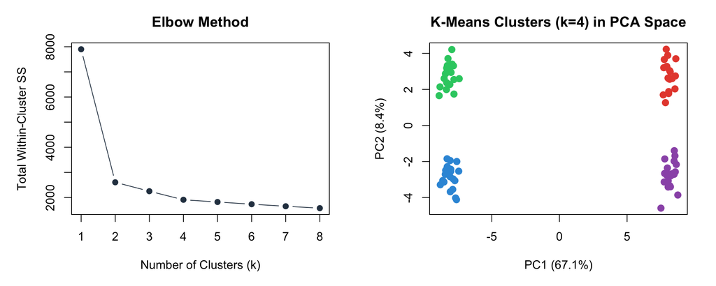

**Code**

```r
# Scale the data
inflam_scaled <- scale(inflam[, gene_cols])

# Elbow method to choose k
set.seed(2026)
wss <- sapply(1:8, function(k) {
  kmeans(inflam_scaled, k, nstart = 25)$tot.withinss
})
plot(1:8, wss, type = "b", pch = 19,
     xlab = "k", ylab = "Total Within-SS", main = "Elbow Method")

# Fit k-means with k = 4
set.seed(2026)
km_fit <- kmeans(inflam_scaled, centers = 4, nstart = 25)

# Visualize in PCA space
plot(pca_scores$PC1, pca_scores$PC2,
     col = km_fit$cluster, pch = 19)

# Compare clusters to actual groups
table(Cluster = km_fit$cluster,
      Group = paste(inflam$strain, inflam$treatment))
```

**Interpretation**

The elbow plot shows a clear bend at k = 2 (Drug vs. Placebo — the dominant signal) and a secondary bend at k = 4 (the four experimental groups). With k = 4, the k-means clusters almost perfectly correspond to the true experimental groups, confirming that the gene expression profiles are strongly structured by treatment and strain. The `nstart = 25` argument runs the algorithm 25 times with different random starting points and keeps the best solution, reducing sensitivity to initialization.

## K-Means vs. Hierarchical Clustering

| Feature | K-Means | Hierarchical |
| --- | --- | --- |
| **Must specify k?** | Yes (in advance) | No (cut tree later) |
| **Cluster shape** | Spherical | Any shape |
| **Scalability** | Fast (large datasets) | Slow (O(n²) or O(n³)) |
| **Deterministic?** | No (random init) | Yes |
| **Visualization** | Scatter plots | Dendrograms |
| **Nested structure?** | No | Yes (dendrogram shows hierarchy) |

**Tip**

Use the **elbow method** or **silhouette scores** to choose k for k-means. Consider running both k-means and hierarchical clustering and comparing results — agreement between methods increases confidence in the groupings.

# K-Nearest Neighbors (KNN)

## What is KNN?

[figure not shown]

## KNN: How It Works

Unlike k-means (unsupervised), **K-Nearest Neighbors** is a **supervised** classification method. It uses labeled training data to classify new, unlabeled observations.

**Algorithm:**

1. For a new observation, calculate its distance to all training points
2. Find the K nearest training points
3. Assign the new observation to the majority class among those K neighbors

**Key properties:**

- **No model training** — KNN is “lazy learning” (stores data, computes at prediction time)
- **Non-parametric** — makes no assumptions about data distribution
- **Flexible decision boundaries** — naturally adapts to complex class shapes
- **Sensitive to feature scaling** — always standardize features before KNN

## KNN: Classifying Mouse Samples

**Output**

```
KNN Classification (k = 5)
```

```
Test set accuracy: 1
```

```
Confusion Matrix:
```

```
                Actual
Predicted        BALB_c_Drug BALB_c_Placebo C57BL6_Drug C57BL6_Placebo
  BALB_c_Drug              8              0           0              0
  BALB_c_Placebo           0              4           0              0
  C57BL6_Drug              0              0           7              0
  C57BL6_Placebo           0              0           0              5
```

**Code**

```r
library(class)

# Prepare data
inflam$group <- paste(inflam$strain, inflam$treatment, sep = "_")
inflam_scaled <- scale(inflam[, gene_cols])

# Train/test split (70/30)
set.seed(2026)
train_idx <- sample(nrow(inflam), 0.7 * nrow(inflam))
train_data <- inflam_scaled[train_idx, ]
test_data <- inflam_scaled[-train_idx, ]
train_labels <- inflam$group[train_idx]
test_labels <- inflam$group[-train_idx]

# KNN classification
knn_pred <- knn(train = train_data, test = test_data,
                cl = train_labels, k = 5)

# Evaluate
mean(knn_pred == test_labels)  # Accuracy
table(Predicted = knn_pred, Actual = test_labels)
```

**Interpretation**

KNN achieves very high accuracy on this dataset because the four experimental groups are well-separated in the 100-dimensional gene expression space. The confusion matrix shows which groups, if any, get confused. With strong drug and strain effects, most misclassifications (if any) occur between same-treatment groups that differ only by strain — the weaker signal.

Note that we split the data into training and test sets to get an honest estimate of performance. Training accuracy would be unrealistically high because the algorithm memorizes training data.

## Choosing K in KNN

**Output**

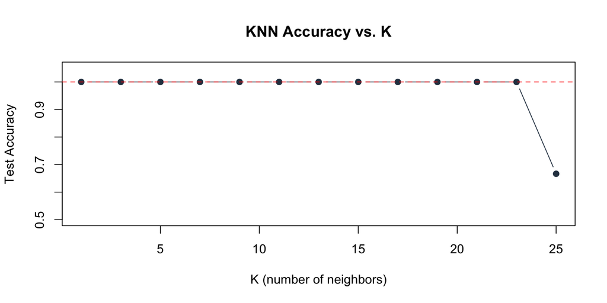

**Code**

```r
# Test multiple k values
k_values <- seq(1, 25, by = 2)
accuracies <- sapply(k_values, function(k) {
  pred <- knn(train = train_data, test = test_data,
              cl = train_labels, k = k)
  mean(pred == test_labels)
})

plot(k_values, accuracies, type = "b", pch = 19,
     xlab = "K", ylab = "Test Accuracy",
     main = "KNN Accuracy vs. K")
```

**Interpretation**

**Small K** (e.g., K = 1) makes very local decisions — high variance, may overfit to noise. **Large K** makes smoother decisions — may underfit and miss real boundaries. The optimal K balances bias and variance. Use odd values of K for binary classification to avoid ties. Cross-validation gives a more robust estimate than a single train/test split.

For this well-separated dataset, many values of K work well. In datasets with more overlap between groups, the choice of K matters more.

## KNN: Important Considerations

**Strengths:**

- Simple, intuitive, no training phase
- Works well when decision boundaries are non-linear
- Naturally handles multi-class problems
- Good baseline for classification tasks

**Limitations:**

- Computationally expensive at prediction time (calculates all distances)
- Sensitive to irrelevant features — all dimensions contribute equally to distance
- Sensitive to feature scaling — must standardize
- “Curse of dimensionality” — distance becomes less meaningful in very high dimensions
- No model to interpret — unlike logistic regression, you can’t examine coefficients

**Tip**

For high-dimensional data like gene expression, consider running PCA first to reduce dimensions, then applying KNN on the top PCs. This reduces noise and computation time.

# Course Summary: Choosing the Right Method

## Which Method Should I Use?

**Start by asking these questions:**

1. **What is your goal?** Inference (understanding) vs. Prediction
2. **What type is your response variable?** Continuous, binary, count, time-to-event, multivariate
3. **How many predictors?** Few vs. many; continuous vs. categorical vs. mixed
4. **Sample size?** Small (n < 30), moderate (30–200), large (200+)

## Method Selection: Inference

| Response | Predictors | Method | Week |
| --- | --- | --- | --- |
| Continuous | 1 continuous | Simple regression | 6 |
| Continuous | Multiple continuous | Multiple regression | 7 |
| Continuous | Continuous + categorical | ANCOVA | 7 |
| Continuous | 1 categorical (2 groups) | t-test / ANOVA | 6 |
| Continuous | Multiple categorical | Multifactor ANOVA | 7 |
| Continuous | Categorical (repeated) | Repeated measures / mixed model | 7–8 |
| Binary | Continuous/mixed | Logistic regression | 8 |
| Count | Continuous/mixed | Poisson / negative binomial regression | 8 |
| Time-to-event | Continuous/mixed | Cox proportional hazards | 8–9 |

## Method Selection: Prediction & Exploration

| Goal | Data Type | Method | Week |
| --- | --- | --- | --- |
| Classify | Labeled, few features | Logistic regression, LDA | 8 |
| Classify | Labeled, complex boundaries | KNN, random forest | 9–10 |
| Reduce dimensions | Continuous | PCA | 10 |
| Reduce dimensions | Distance/dissimilarity | PCoA, NMDS | 10 |
| Visualize clusters | High-dimensional | t-SNE, UMAP | 10 |
| Find groups | No labels | K-means, hierarchical clustering | 10 |
| Test group differences | Distance matrix | PERMANOVA | 10 |

## Reporting Effect Sizes

P-values tell you **whether** an effect exists; effect sizes tell you **how large** it is. Always report both.

| Method | Effect Size Measure | R Code |
| --- | --- | --- |
| t-test | Cohen’s d | `effectsize::cohens_d()` |
| ANOVA | η² (eta-squared), ω² | `effectsize::eta_squared()` |
| Regression | R², partial R² | `summary(model)$r.squared` |
| Logistic regression | Odds ratio | `exp(coef(model))` |
| Cox PH | Hazard ratio | `exp(coef(model))` |
| PERMANOVA | R² | `adonis2()` output |

**Important**

“Statistical significance does not imply practical importance.” A tiny effect can be highly significant with a large enough sample. Effect sizes help you assess whether the difference matters in your bioengineering application.

## Reproducibility Checklist

For every analysis in this course and beyond:

1. **Set a seed** (`set.seed()`) for any analysis involving randomness
2. **Report package versions** (`sessionInfo()` or `renv::snapshot()`)
3. **Use relative paths** and organized project directories
4. **Document your analysis** in Quarto/R Markdown (literate programming)
5. **Report effect sizes** alongside p-values
6. **Share your code** — reproducibility requires transparency